# Introduciton to StatComp20006

Yulin Li

2020-12-20

## Overview

**StatComp20006** is a simple R package developed to show my homeworks in the 'Statistical Computing' course. Besides, it also contains two functions *knn.est* and *Tstat*.

## Homework-09-22

## Question

Use knitr to produce 3 examples in the book.

The 1st example should contain texts and at least one figure.

The 2nd example should contains texts and at least one table.

The 3rd example should contain at least a couple of LaTeX formulas.

## Answer

### Q1

The 1st answer contains texts and at least one figure.

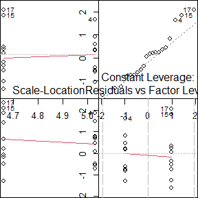

```r
ctl <- c(4.17,5.58,5.18,6.11,4.50,4.61,5.17,4.53,5.33,5.14)
trt <- c(4.81,4.17,4.41,3.59,5.87,3.83,6.03,4.89,4.32,4.69)
group <- gl(2, 10, 20, labels = c("Ctl","Trt"))
weight <- c(ctl, trt)
lm.D9 <- lm(weight ~ group)
par(mfrow=c(2,2),mar=rep(0,4))
plot(lm.D9)
```

### Q2

The 2nd answer contains texts and at least one table.

```r
knitr::kable(head(iris))
```

| Sepal.Length | Sepal.Width | Petal.Length | Petal.Width | Species |
| --- | --- | --- | --- | --- |
| 5.1 | 3.5 | 1.4 | 0.2 | setosa |
| 4.9 | 3.0 | 1.4 | 0.2 | setosa |
| 4.7 | 3.2 | 1.3 | 0.2 | setosa |
| 4.6 | 3.1 | 1.5 | 0.2 | setosa |
| 5.0 | 3.6 | 1.4 | 0.2 | setosa |
| 5.4 | 3.9 | 1.7 | 0.4 | setosa |

### Q3

The 3rd answer contains at least a couple of LaTeX formulas.

$$\bar{X}=\frac{1}{n}\sum_{i=1}^nX_i$$

$$\begin{align*}
a_1x_1+b_1x_2=c_1 \\
b_1x_1+b_2x_2=c_2
\end{align*}$$

## Homework-09-29

## Exercise 3.3

The Pareto(a, b) distribution has cdf

$$\displaystyle F(x)=1-(\frac{b}{x})^a,~~~~~~~x \geq b >0,~a>0.$$

Derive the probability inverse transformation $F^{-1}(U)$ and use the inverse transform method to simulate a random sample from the Pareto(2,2) distribution. Graph the density histogram of the sample with the Pareto(2,2) density superimposed for comparison.

### answer

The inverse function:

$$\displaystyle F^{-1}(x)=\frac{b}{\sqrt[a]{1-x}}~~~~~~~0 \leq x \leq 1,~a>0$$
,

The pdf of the Pareto(a,b) distribution is

$$f(x)=\displaystyle \frac{ab^a}{x^{a+1}},~~~~~~~x \geq b >0,~a>0$$

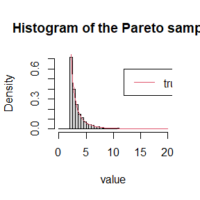

```r
n <- 10000
a <- 2
b <- 2
unifrv <- runif(n)
paretorv <- b/(1-unifrv)^(1/a)    # inverse transformation
hist(paretorv[paretorv>0 & paretorv<20], freq = FALSE, breaks = seq(0,20,0.5), main = "Histogram of the Pareto sample", xlab = "value")    # graph the density histogram
f <- function(x) {a*b^a/x^(a+1)}    # true pdf
curve(f, 2, 20, col = 2, add = TRUE)    # add the true density curve
legend(12,0.6,"true density", col = 2, lwd = 1)    # add a legend
```

## Exercise 3.9

The rescaled Epanechnikov kernel is a symmetric density function

$$\displaystyle f_e(x)=\frac{3}{4}(1-x^2),~~~~~~~|x| \leq 1$$

Devroye and Gyorfi give the following algorithm for simulation from this distribution. Generate iid $U_1,U_2,U_3 \sim$ Uniform(-1,1). If $|U_3|\geq|U_2|$ and $|U_3|\geq|U_1|$, deliver $U_2$; otherwise deliver $U_3$. Write a function to generate random variates from $f_e$, and construct the histogram density estimate of a large simulated random sample.

### answer

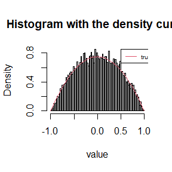

```r
u1 <- runif(10000, min = -1, max = 1)    # n = 10000
u2 <- runif(10000, min = -1, max = 1)
u3 <- runif(10000, min = -1, max = 1)
u <- ifelse((abs(u3)>abs(u2) & abs(u3)>abs(u1)), u2, u3)
hist(u, freq = FALSE, breaks = seq(-1,1,0.02), main = "Histogram with the density curve", xlab = "value")
f <- function(x) {3/4*(1-x^2)}
curve(f, -1, 1, col = 2, add = TRUE)
legend(0.5,0.85,"true density", col = 2, lwd = 1, cex=0.6)    # add a legend
```

## Exercise 3.10

Prove that the algorithm given in Exercise 3.9 generates variates from the density $f_e$

### answer

Let $X_1=|U_1|, X_2=|U_2|, X_3=|U_3|$,then clearly there is $X_1,X_2,X_3 \sim$ Uniform(0,1).

Let $X= \begin{cases} X_2 & ~~X_3 \geq X_1~~and~~ X_3 \geq X_2 \\ X_3 & ~~otherwise \\ \end{cases}$
Then, since $f_e(x)$ is symmetric, all I have to prove is that $X$ obeys the pdf
$$f_{e'}(x)=2*\frac{3}{4}(1-x^2),~~~~~~~0 \leq x \leq 1$$

Now, notice that the algorithm to generate $X$ can be rewritten as:

1. Generate $X_1,X_2,X_3 \sim$ Uniform(0,1).
2. Remove the largest value $X_{(3)}$
3. Select one of the remaining two values with equal probability. Let $X$ be this value.

For any $0 \leq x \leq 1$, consider the events:  
$A=\{$ only one of the $X_i \leq x$ $\}$  
$B=\{$ at least two of the $X_i \leq x$ $\}$,  
Then, it's easy to compute the cdf of $X$, $F_{e'}(x)$ as following:

$$\begin{align}
F_{e'}(x)&=P(X\leq x)\\
&=P(X \leq x,A)+P(X \leq x,B)\\
&=P(X \leq x~|~A)*P(A) + P(X \leq x~|~B)*P(B)\\
&=\frac{1}{2}*3x(1-x)^2 + 1*[3x^2(1-x) + x^3]\\
&=-\frac{1}{2} x^3 +\frac{3}{2}x,~~~~~~0 \leq x \leq 1
\end{align}$$

Thus, the pdf of $X$ is
$$f_{e'}(x)=F'_{e'}(x)=2*\frac{3}{4}(1-x^2),~~~~~~~0 \leq x \leq 1$$

Thus, the algorithm given in Exercise 3.9 generates variates from the density $f_e. ~~~ \Box$

## Exercise 3.13

It can be shown that the mixture in Exercise 3.12 has a Pareto distribution with cdf
$$F(y)=1-\Big(\frac{\beta}{\beta+y}\Big)^r,~~~~~~~y\geq0$$

(This is an alternative parameterization of the Pareto cdf given in Exercise 3.3.) Generate 1000 random observations from the mixture with $r=4$ and $\beta=2$. Compare the empirical and theoretical (Pareto) distributions by graphing the density histogram of the sample and superimposing the Pareto density curve.

### answer

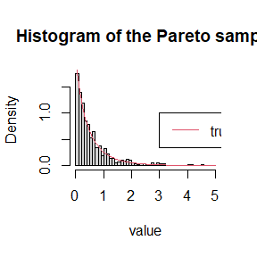

```r
n <- 1000
r <- 4
beta <- 2
gammarv <- rgamma(n, shape = r, rate = beta)
x <- rexp(n, rate = gammarv)
hist(x[x<5], freq = FALSE, breaks = seq(0,5,0.1), main = "Histogram of the Pareto sample", xlab = "value")
f <- function(x) {64/(2+x)^5}    # pdf of Pareto distribution
curve(f, 0, 5, col = 2, add = TRUE)
legend(3, 1, "true density", col = 2, lwd = 1)    # add a legend
```

## Homework-10-13

## Question

5.1 Compute a Monte Carlo estimate of
$$\begin{equation}
\int_{0}^{\pi/3}\sin t\,\mathrm{d}t
\end{equation}$$

and compare your estimate with the exact value of the integral.

## Answer

$$\int_a^b h(x)dx = \int_a^b g(x)\frac1{b-a}dx=E[g(X)],$$
where $X\sim U(a,b),g(x)=(b-a)h(x).$

So we have:
$$\int_{0}^{\pi/3}\sin t\,\mathrm{d}t = \frac{\pi}{3}E[\sin X], X\sim U(0,\frac{\pi}{3}).$$

Then we can compute a Monte Carlo estimate of it:

```r
set.seed(1)
m <- 1e5
x <- runif(m, min=0, max=pi/3)
theta.hat <- mean(sin(x)) * pi / 3
```

The estimate and true value:

```r
c(theta.hat, 1/2)
```

```
## [1] 0.4995378 0.5000000
```

## Question

5.7 Refer to Exercise 5.6. Use a Monte Carlo simulation to estimate $\theta$ by the antithetic variate approach and by the simple Monte Carlo method. Compute an empirical estimate of the percent reduction in variance using the antithetic variate. Compare the result with the theoretical value from Exercise 5.6.

## Answer

We give a simple estimator:
$$\begin{equation}
\hat{\theta}_1 = \frac{1}{m}\sum\limits_{j=1}^{m}e^{X_{j}},X_{j}\sim U(0,1).
\end{equation}$$

Estimate $\theta$ by the simple Monte Carlo method:

```r
set.seed(2)
m <- 1e6
x1 <- runif(m, min=0, max=1)
theta_hat_1 <- exp(x1)
```

We give a estimator by the antithetic variate approach:
$$\begin{equation}
\hat\theta_2 = \frac{1}{m}\sum\limits_{j=1}^{m/2}(e^{X_{j}}+e^{1-X_{j}}),X_{j}\sim U(0,1).
\end{equation}$$

Estimate $\theta$ by the antithetic variate approach:

```r
set.seed(3)
m <- 5e5
x2 <- runif(m, min=0, max=1);
theta_hat_2 <- (exp(x2) + exp(1-x2)) / 2
```

Compute an empirical estimate of the percent reduction in variance using the antithetic variate:

```r
c(1-var(theta_hat_2) / var(theta_hat_1))
```

```
## [1] 0.9838787
```

$$\theta=\int_0^1 e^xdx$$
$$Var(e^U)=E(e^{2U})-(E(e^U))^2=\int_0^1 e^{2x}dx-(\int_0^1 e^{x}dx)^2=\frac{1}{2}(e^2-1)-(e-1)^2=0.2420$$
$$Cov(e^U,e^{1-U})=E(e^{U+1-U)})-E(e^U)E(e^{1-U})=e-\int_0^1e^xdx \int_0^1e^{1-x}dx=-0.2342$$
$$Var((e^U+e^{1-U})/2)=Var(e^U)/4+Var(e^{1-U})/4+Cov(e^U,e^{1-U})/2=0.0039$$

Thus, the theoretical value of percent reduction is $1-0.0039/0.2420=98.39\%$

## Question

5.11 If $\hat\theta_{1}$ and $\hat\theta_{2}$ are unbiased estimators of $\theta$, and $\hat\theta_{1}$ and $\hat\theta_{2}$ are antithetic, we derived that $c^{*} = 1/2$ is the optimal constant that minimizes the variance of $\hat\theta_{c} = c\hat\theta_{1} + (1-c)\hat\theta_{2}$. Derive $c^{*}$ for the general case. That is, if $\hat\theta_{1}$ and $\hat\theta_{2}$ are any two unbiased estimators of $\theta$, find the value $c^{*}$ that minimizes the variance of the estimator $\hat\theta_{c} = c\hat\theta_{1}+(1-c)\hat\theta_{2}$ in equation (5.11). ($c^{*}$ will be a function of the variances and the covariance of the estimators.)

## Answer

$$\begin{align}
var(\hat\theta_c)&=c^2var(\hat\theta_1)+(1-c)^2var(\hat\theta_2)+2c(1-c)Cov(\hat\theta_1,\hat\theta_2)\\
&=(var(\hat\theta_1)+var(\hat\theta_2)-2Cov(\hat\theta_1,\hat\theta_2))c^2+2c(Cov(\hat\theta_1,\hat\theta_2)-var(\hat\theta_2))+var(\hat\theta_2) \\
&=var(\hat\theta_1-\hat\theta_2)c^2+2(Cov(\hat\theta_1,\hat\theta_2)-var(\hat\theta_2))c+var(\hat\theta_2)
\end{align}$$

So, $c^*= \begin{cases} 0 & ~~~~ \frac{Var(\hat{\theta}_2)-Cov(\hat{\theta}_1,\hat{\theta}_2)}{Var(\hat{\theta}_1)+Var(\hat{\theta}_2)-2Cov(\hat{\theta}_1,\hat{\theta}_2)} <0\\ \frac{Var(\hat{\theta}_2)-Cov(\hat{\theta}_1,\hat{\theta}_2)}{Var(\hat{\theta}_1)+Var(\hat{\theta}_2)-2Cov(\hat{\theta}_1,\hat{\theta}_2)} &~~~~ 0 \leq \frac{Var(\hat{\theta}_2)-Cov(\hat{\theta}_1,\hat{\theta}_2)}{Var(\hat{\theta}_1)+Var(\hat{\theta}_2)-2Cov(\hat{\theta}_1,\hat{\theta}_2)} \leq 1 \\ 1 & ~~~~ \frac{Var(\hat{\theta}_2)-Cov(\hat{\theta}_1,\hat{\theta}_2)}{Var(\hat{\theta}_1)+Var(\hat{\theta}_2)-2Cov(\hat{\theta}_1,\hat{\theta}_2)} >1\\ \end{cases}$ minimizes the variance of the estimator.

## Homework-10-20

## Exercise 5.13

Find two importance functions $f_1$ and $f_2$ that are supported on $(1,\infty)$ and are 'close' to
$$g(x) = \frac{x^2}{\sqrt{2\pi}}e^{-x^2/2},\quad x>1.$$

Which of your importance functions should produce the smaller variance in estimating
$$\int_1^{\infty}\frac{x^2}{\sqrt{2\pi}}e^{-x^2/2}\,dx,$$

by importance sampling? Explain.

## Answer 5.13

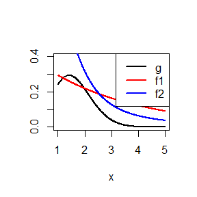

```r
#figure 1
x <- seq(1,5,.01)
g <- x^2/sqrt(2*pi)*exp(-x^2/2)
lambda <- sqrt(2/pi)/exp(1)
f1 <- lambda*exp(-lambda*(x-1))
f2 <- 2/pi/(1+(x-1)^2)
plot(x,g,type="l",main="",ylab="",ylim = c(0,0.4),lwd=2)
lines(x,f1,col='red',lwd=2)
lines(x,f2,col='blue',lwd=2)
legend("topright",legend = c("g","f1","f2"),col=c("black","red","blue"),lwd = 2)
```

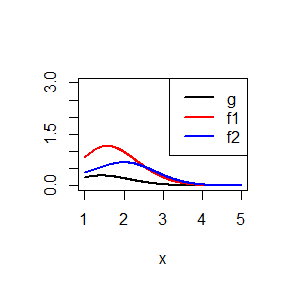

```r
#figure 2
plot(x, g, type = "l", main = "", ylab = "",
ylim = c(0,3), lwd = 2)
lines(x, g/f1, col='red', lwd = 2)
lines(x, g/f2, col='blue', lwd = 2)
legend("topright",legend = c("g","f1","f2"),col=c("black","red","blue"),lwd = 2)
```

```r
m <- 1e4
theta.hat <- se <- numeric(2)
g <- function(x){
  x^2/sqrt(2*pi)*exp(-x^2/2)
}
f1 <- function(x,lambda){
  lambda*exp(-lambda*(x-1))
}
f2 <- function(x){
  2/pi/(1+(x-1)^2)
}

#using f1
x <- rexp(m,lambda)+1
fg <- g(x)/f1(x,lambda=lambda)
theta.hat[1] <- mean(fg)
se[1] <- sd(fg)
#using f2
u <- runif(m)
x <- tan(pi*u/2)+1
fg <- g(x)/f2(x)
theta.hat[2] <- mean(fg)
se[2] <- sd(fg)

rbind(theta.hat,se)
```

```
##                [,1]      [,2]
## theta.hat 0.4016048 0.4009808
## se        0.4610494 0.2469858
```

From the above result, we know that the f2 function produce smaller variance. We can see the reason from Figure 2, since $g(x)/f_2(x)$ is more like a constant.

## Exercise 5.15

Obtained the stratified importance sampling estimate in Example 5.13 and compare it with the result of Example 5.10.

## Answer 5.15

At first, we calculate the 5 intervals $I_j=\{a_{j-1}\le x<a_j\}$ with endpoints $a_0=0,\,a_5=1,\,a_j=F^{-1}(j/5),\,j=1,\dots,4$.

```r
u <- seq(0,1,.2)
a <- -log(1-(exp(1)-1)/exp(1)*u)
```

Thus, on each interval $I_j$, the conditional density $f_j$ is defined as
$$f_j(x) = \frac{5e^{-x}}{1-e^{-1}},\quad a_{j-1}<x<a_j,$$

For each $j$, we calculate the corresponding cdf $F_j(x)$ and its inverse function $F_j^{-1}(U)$ as below.

$$\begin{aligned}
F_j(x)&=\frac{5(1-e^{-x})}{1-e^{-1}}-(j-1),\quad j=1,\cdots,5,\\
F_j^{-1}(u)&=-\ln\left(1-\frac{e-1}{5e}(u+j-1)\right).
\end{aligned}$$

```r
inverse.F <- function(u,j){
  -log(1-(exp(1)-1)/(5*exp(1))*(u+j-1))
}
g <- function(x) {
  exp(-x - log(1+x^2)) * (x > 0) * (x < 1)
}
f <- function(x){
  exp(-x)/(1-exp(-1))
}

M <- 10000  #number of replicates
k <- 5     #number of strata
r <- M / k  #replicates per stratum
N <- 50     #number of times to repeat the estimation
T2 <- numeric(k)
estimates <- matrix(0,N,2)
set.seed(123)
for (i in 1:N) {
  u <- runif(M)
  x <- - log(1 - u * (1 - exp(-1)))
  fg <- g(x) / f(x)
  estimates[i,1] <- mean(fg)
  for (j in 1:k) {
    u <- runif(r)
    x <- inverse.F(u,j)
    fg <- g(x) / f(x)
    T2[j] <- mean(fg)
  }
  estimates[i,2] <- mean(T2)
}

apply(estimates, 2, mean)
```

```
## [1] 0.5248617 0.5248590
```

```r
apply(estimates, 2, var)
```

```
## [1] 9.098016e-07 3.851241e-08
```

From the result above, we can see that the stratified importance sampling estimate produced samller variance compared to the importance sampling estimate.

## Exercise 6.4

Suppose that $X_1,\dots,X_n$ are a random sample from a lognormal distribution with unknown parameters. Construct a 95% condifence interval for the parameter $\mu$. Use a Monte Carlo method to obtain an empirical estimate of the confidence level.

## Answer 6.4

Suppose that $\log(X_1),\cdots,\log(X_n)\,\sim N(\mu,\sigma^2)$. Let $Y_i = \log(X_i),\,i=1,\cdots,n$, then we have
$$T=\frac{\bar{Y}-\mu}{\sqrt{S^2/n}}\sim t(n-1)$$

where $S^2=\frac1{n-1}\sum_{i=1}^n(Y_i-\bar{Y})^2$. Then a 95% CI for $\mu$ is
$$\left(\bar{Y}-\frac{S}{\sqrt{n}}t_{0.025}(n-1),\,\bar{Y}+\frac{S}{\sqrt{n}}t_{0.025}(n-1)\right)$$

To estimate the condifence level, we only need to generate random samples from $N(\mu,\sigma^2)$ rather than from lognormal distribution. In this solution, we suppose $\mu=0,\,\sigma=1, n=10,\,m=1000$ replicates.

```r
n <- 10; m <- 1000
alpha <- .05
CI <- matrix(0,m,2)
set.seed(123)
for (i in 1:m) {
  x <- rnorm(n)
  CI[i,1] <- mean(x)-sd(x)/sqrt(n)*qt(1-alpha/2,n-1)
  CI[i,2] <- mean(x)+sd(x)/sqrt(n)*qt(1-alpha/2,n-1)
}
#confidence level
mean(CI[,1]<0&CI[,2]>0)
```

```
## [1] 0.955
```

## Exercise 6.5

Suppose a 95% symmetric t-interval is applied to estimate a mean, but the sample data are non-normal. Then the probability that the confidence interval covers the mean is not necessarily equal to 0.95. Use a Monte Carlo experiment to estimate the coverage probability of the t-interval for random samples of $\chi^2(2)$ data with sample size $n = 20$. Compare your t-interval results with the simulation results in Example 6.4. (The t-interval should be more robust to departures from normality than the interval for variance.)

## Answer 6.5

```r
n <- 10; m <- 1000
alpha <- .05
CI <- matrix(0,m,2)
set.seed(123)
for (i in 1:m) {
  x <- rchisq(n,df = 2)
  CI[i,1] <- mean(x)-sd(x)/sqrt(n)*qt(1-alpha/2,n-1)
  CI[i,2] <- mean(x)+sd(x)/sqrt(n)*qt(1-alpha/2,n-1)
}
#confidence level
mean(CI[,1]<2&CI[,2]>2)
```

```
## [1] 0.887
```

Remark: now the sampled population is $\chi^2(2)$ and it has mean 2.

From the ECP above, we can see that the t-interval is more robust to departures from normality compared to the interval for variance.

## Homework-10-27

## 6.7

Estimate the power of the skewness test of normality against symmetric $Beta(α, α)$ distributions and comment on the results. Are the results different for heavy-tailed symmetric alternatives such as $t(ν)$?

## Answer

use the method like the text book

```r
library(StatComp20006)
```

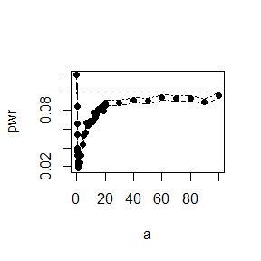

```r
 a = c(seq(0,1,0.1),seq(1,20,1),seq(20,100,10))
 pwr = pwr_beta(a)$pwr
 # plot the power
 se = pwr_beta(a)$se
 plot(a, pwr, type = "b", xlab = "a", ylab = "pwr", pch=16)
 abline(h = 0.1, lty = 2)
 lines(a, pwr+se, lty = 4)
 lines(a, pwr-se, lty = 4)
```

The power of the skewness test of normality against symmetric Beta(a,a) distribution is under 0.1. For a< 1, the empirical power is more and more far away from 0.1 With the increase of a. And for a>1, the empirical power increases to 0.1 when a increases.

```r
# t(v)
pwr_t = function(v){

 alpha = 0.1
 n = 20
 m = 1e3
 N = length(v)
 pwr = numeric(N)
 cv = qnorm(1-alpha/2, 0, sqrt(6*(n-2) / ((n+1)*(n+3))))

 for (j in 1:N) {
  sktests = numeric(m)
  for (i in 1:m) {
   x = rt(n,v[j])
   sktests[i] = as.integer(abs(sk(x))>= cv)
  }
  pwr[j] = mean(sktests)
 }
 se = sqrt(pwr*(1-pwr) / m)
  return(list(pwr = pwr,se = se))
}
```

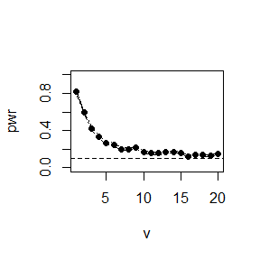

```r
library(StatComp20006)
v = seq(1,20)
pwr = pwr_t(v)$pwr
se = pwr_t(v)$se
# plot the power
plot(v, pwr, type = "b", xlab = "v", ylab = "pwr", ylim = c(0,1),pch=16)
abline(h = 0.1, lty = 2)
lines(v, pwr+se, lty = 4)
lines(v, pwr-se, lty = 4)
```

The results are different for heavy-tailed symmetric alternatives. For t distribution, the empirical power is always bigger than 0.1 and it decreases to 0.1 with the increase of v.

## 6.8

Refer to Example 6.16. Repeat the simulation, but also compute the F test of equal variance, at significance level $ 0.055 $ Compare the power of the Count Five test and F test for small, medium, and large sample sizes. (Recall that the F test is not applicable for non-normal distributions.)

## Answer

```r
pwr_F <- function(n,alpha.hat){
  mu1 <- mu2 <- 0
  sigma1 <- 1
  sigma2 <- 1.5
  m <- 1e4
  result <- matrix(0, length(n), 2)
  for (i in 1:length(n)){
    ni <- n[i]
    tests <- replicate(m, expr={
      x <- rnorm(ni, mu1, sigma1)
      y <- rnorm(ni, mu2, sigma2)
      Fp <- var.test(x, y)$p.value
      Ftest <- as.integer(Fp <= alpha.hat)
      c(count5test(x, y), Ftest)
    })
    result[i, ] <- rowMeans(tests)
  }
  data.frame(n=n, C5=result[, 1], Fp=result[, 2])
}
```

```r
library(StatComp20006)
set.seed(1027)
alpha.hat <- 0.055
n <- c(10, 20, 50, 100, 500, 1000)
pwr <- pwr_F(n,alpha.hat)
print(pwr)
```

```
##      n     C5     Fp
## 1   10 0.1050 0.2101
## 2   20 0.3128 0.4248
## 3   50 0.6584 0.8181
## 4  100 0.8546 0.9812
## 5  500 0.9902 1.0000
## 6 1000 0.9977 1.0000
```

The simulation results suggest that the F-test for equal variance is more powerful in this case, for all sample sizes compared.

## 6.C

Repeat Examples 6.8 and 6.10 for Mardia’s multivariate skewness test. Mardia proposed tests of multivariate normality based on multivariate generalizations of skewness and kurtosis. If X and Y are iid, the multivariate population skewness $\beta_{1,d}$ is defined by Mardia as
$$\beta_{1,d}=E[(X-\mu)^T \Sigma^{-1}(Y-\mu)]^3$$
Under normality,$\beta_{1,d}=0$ . The multivariate skewness statistic is
$$b_{1,d}=\frac{1}{n^2} \sum_{i,j=1}^n {((X_i-\bar{X})^T \hat{\Sigma}^{-1} (X_j-\bar{X}))^3}$$
where $\hat{\Sigma}$is the maximum likelihood estimator of covariance. Large values of $b_{1,d}$ are significant. The asymptotic distribution of $\frac{nb_{1,d}}{6}$ is chisquared with $\frac{d(d + 1)(d + 2)}{6}$ degrees of freedom.

## Answer

We first repeat Example 6.8 which evaluate t1e rate of Mardia’s multivariate skewness test. In our simulation we generate variables following $N(\mu,\Sigma)$, where:
$$\mu=(0,0,0)^{T} , \Sigma=\left( \begin{array}{ccc}
1 & 0 & 0 \\
0 & 1 & 0 \\
0 & 0 & 1 \end{array} \right).$$

```r
library(MASS)
library(StatComp20006)
set.seed(1234)
mu <- c(0,0,0)
sigma <- matrix(c(1,0,0,0,1,0,0,0,1),nrow=3,ncol=3)
m=1000
n<-c(10, 20, 30, 50, 100, 500)
#m: number of replicates; n: sample size
a=numeric(length(n))
for(i in 1:length(n)){
  a[i]=mean(replicate(m, expr={
    mydata <- mvrnorm(n[i],mu,sigma)
    Mardia(mydata)
  }))
}
```

We calculate the t1e when the sample size is 10, 20, 30, 50, 100, 500:

```r
print(a)
```

```
## [1] 0.001 0.017 0.036 0.049 0.046 0.054
```

From the result we can see that t1e rate is close to 0.05 after the sample size is large than 50.

We further repeat Example 6.8 which evaluate the power of Mardia’s multivariate skewness test under distribution $(1-\epsilon)N(\mu_{1},\Sigma_{1})+\epsilon N(\mu_{2},\Sigma_{2})$, where:
$$\mu_{1}=\mu_{2}=(0,0,0)^{T}, \Sigma_{1}=\left( \begin{array}{ccc}
1 & 0 & 0 \\
0 & 1 & 0 \\
0 & 0 & 1 \end{array} \right)
\Sigma_{2}=\left( \begin{array}{ccc}
100 & 0 & 0 \\
0 & 100 & 0 \\
0 & 0 & 100 \end{array} \right).$$

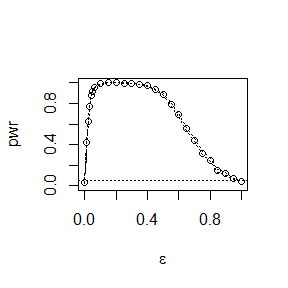

```r
library(MASS)
set.seed(7912)
set.seed(7912)
mu1 <- mu2 <- c(0,0,0)
sigma1 <- matrix(c(1,0,0,0,1,0,0,0,1),nrow=3,ncol=3)
sigma2 <- matrix(c(100,0,0,0,100,0,0,0,100),nrow=3,ncol=3)
sigma=list(sigma1,sigma2)
m=1000
n=50
#m: number of replicates; n: sample size
epsilon <- c(seq(0, .06, .01), seq(.1, 1, .05))
N <- length(epsilon)
pwr <- numeric(N)
for (j in 1:N) { #for each epsilon
  e <- epsilon[j]
  sktests <- numeric(m)
  for (i in 1:m) { #for each replicate
    index=sample(c(1, 2), replace = TRUE, size = n, prob = c(1-e, e))
    mydata<-matrix(0,nrow=n,ncol=3)
    for(t in 1:n){
      if(index[t]==1) mydata[t,]=mvrnorm(1,mu1,sigma1)
      else mydata[t,]=mvrnorm(1,mu2,sigma2)
    }
    sktests[i] <- Mardia(mydata)
  }
  pwr[j] <- mean(sktests)
}
plot(epsilon, pwr, type = "b",
     xlab = bquote(epsilon), ylim = c(0,1))
abline(h = .05, lty = 3)
se <- sqrt(pwr * (1-pwr) / m) #add standard errors
lines(epsilon, pwr+se, lty = 3)
lines(epsilon, pwr-se, lty = 3)
```

When $\epsilon=0$ or $\epsilon=1$ the distribution is multinormal, when $0\leq \epsilon \leq 1$ the empirical power of the test is greater than 0.05 and highest(close to 1) when $0.1\leq \epsilon \leq 0.3$.

## Discussion

If we obtain the powers for two methods under a particular simulation setting with 10,000 experiments: say, 0.651 for one method and 0.676 for another method. Can we say the powers are different at 0.05 level?

- What is the corresponding hypothesis test problem?
- What test should we use? Z-test, two-sample t-test, paired-t test or McNemar test?
- What information is needed to test your hypothesis?

## Answer

1. Denote the powers of two methods as $pwr_{1}$ and $pwr_{2}$, then the corresponding hypothesis test problem is:
   $$H_{0}: pwr_{1}=pwr_{2} \leftrightarrow H_{1}: pwr_{1}\not=pwr_{2}.$$
2. As the p-value of two methods for the same sample is not independent, we can not apply the two-sample t-test. For the z-test and paired-t test, when the sample size is large, we have the mean value of significance test follows a normal distribution, thus these two methods can be used in the approximate level. McNemar test is good at dealing with this case as it doesn't need to know the distribution.
3. For these test, what we already know is the number of experiments and the value of power(the probability that we reject the null hypothesis correctly). To conduct this test, we also need to know the significance of both methods for each sample.

## Homework-11-03

## 7.1

Compute a jackknife estimate of the bias and the standard error of the correlation statistic in Example 7.2.

## Answer

```r
jack_correlation <- function(x,y){
  n <- length(x)
  theta_hat <- cor(x,y)
  theta_jack <- numeric(n)
  for(i in 1:n){
    theta_jack[i] <- cor(x[-i],y[-i])
  }
  bias_jack <- (n-1)*(mean(theta_jack)-theta_hat)
  se_jack <- sqrt((n-1)*mean((theta_jack-mean(theta_jack))^2))
  c(bias_jack = bias_jack,se_jack = se_jack)
}
```

```r
library(StatComp20006)
data(law)
attach(law)
jack_est <- jack_correlation(LSAT,GPA)
print(round(jack_est,4))
```

```
## bias_jack   se_jack
##   -0.0065    0.1425
```

```r
detach(law)
```

## 7.5

Refer to Exercise 7.4. Compute $95%$ bootstrap confidence intervals for the mean time between failures $1/\lambda$ by the standard normal, basic, percentile, and BCa methods. Compare the intervals and explain why they may differ.

## Answer

```r
boot_ci <- function(x){
  boot.mean <- function(x,i) mean(x[i])
  boot.obj <- boot(x,statistic = boot.mean,R=2000)
  boot.ci(boot.obj,type = c("norm","basic","perc","bca"))
}
```

```r
library(StatComp20006)
data(aircondit)
aircondit <- as.matrix(aircondit)
bo <- boot_ci(aircondit)
print(bo)
```

```
## BOOTSTRAP CONFIDENCE INTERVAL CALCULATIONS
## Based on 2000 bootstrap replicates
##
## CALL :
## boot.ci(boot.out = boot.obj, type = c("norm", "basic", "perc",
##     "bca"))
##
## Intervals :
## Level      Normal              Basic
## 95%   ( 32.3, 182.1 )   ( 24.4, 169.7 )
##
## Level     Percentile            BCa
## 95%   ( 46.5, 191.7 )   ( 55.4, 218.2 )
## Calculations and Intervals on Original Scale
```

## 7.8

Refer to Exercise 7.7. Obtain the jackknife estimates of bias and standard error of $\hat\theta$.

## Answer

```r
jack_pca <- function(X){
  n <- nrow(X)
  lambda_hat = eigen(cov(X))$values
  theta_hat = lambda_hat[1] / sum(lambda_hat)
  theta_j = rep(0,n)
  for (i in 1:n) {
    x = X[-i,]
    lambda = eigen(cov(x))$values
    theta_j[i] = lambda[1]/sum(lambda)
  }
  #estimated bias of theta_hat
  bias_jack = (n-1)*(mean(theta_j)-theta_hat)
  #estimated se of theta_hat
  se_jack = (n-1)*sqrt(var(theta_j)/n)
  c(bias_jack = bias_jack,se_jack=se_jack)
}
```

```r
library(StatComp20006)
data(scor)
ja <- jack_pca(scor)
print(round(ja,4))
```

```
## bias_jack   se_jack
##    0.0011    0.0496
```

## 7.11

In Example 7.18, leave-one-out ($n$-fold) cross validation was used to select the best fitting model. Use leave-two-out cross validation to compare the models.

## Answer

```r
leave2out_cv <- function(X,Y){
  n <- length(X)
  e1 <- e2 <- e3 <- e4 <- matrix(0,n*(n-1)/2,2)
  for(i in 2:n){
    for(j in 1:(i-1)){
      k <- (i-1)*(i-2)/2 + j
      y <- Y[-c(i,j)]
      x <- X[-c(i,j)]

      J1 <- lm(y ~ x)
      yhat1 <- J1$coef[1] + J1$coef[2] * X[c(i,j)]
      e1[k,] <- Y[c(i,j)]- yhat1

      J2 <- lm(y ~ x + I(x^2))
      yhat2 <- J2$coef[1] + J2$coef[2] * X[c(i,j)] + J2$coef[3] * X[c(i,j)]^2
      e2[k,] <- Y[c(i,j)] - yhat2

      J3 <- lm(log(y) ~ x)
      logyhat3 <- J3$coef[1] + J3$coef[2] * X[c(i,j)]
      yhat3 <- exp(logyhat3)
      e3[k,] <- Y[c(i,j)] - yhat3

      J4 <- lm(log(y) ~ log(x))
      logyhat4 <- J4$coef[1] + J4$coef[2] * log(X[c(i,j)])
      yhat4 <- exp(logyhat4)
      e4[k,] <- Y[c(i,j)] - yhat4
    }
  }
  c(mean(e1^2), mean(e2^2), mean(e3^2), mean(e4^2))
}
```

```r
library(StatComp20006)
data(ironslag)
attach(ironslag)
cv <- leave2out_cv(chemical,magnetic)
print(cv)
```

```
## [1] 19.57227 17.87018 18.45491 20.46718
```

```r
detach(ironslag)
```

## Homework-11-10

## Question

8.3 The Count 5 test for equal variances in Section 6.4 is based on the maximum number of extreme points. Example 6.15 shows that the Count 5 criterion is not applicable for unequal sample sizes. Implement a permutation test for equal variance based on the maximum number of extreme points that applies when sample sizes are not necessarily equal.

## Answer

```r
# Count Five test
count5test = function(x, y) {
X = x - mean(x)
Y = y - mean(y)
outx = sum(X > max(Y)) + sum(X < min(Y))
outy = sum(Y > max(X)) + sum(Y < min(X))
# return 1 (reject) or 0 (do not reject H0)
return(as.integer(max(c(outx, outy)) > 5))
}
# Count Five test permutation
count5test_permutation <- function(z,R){
  permutation <- function(z){
    n <- length(z)
    x <- z[1:(n/2)]
    y <- z[-(1:(n/2))]
    X <- x-mean(x)
    Y <- y-mean(y)
    outx <- sum(X > max(Y)) + sum(X < min(Y))
    outy <- sum(Y > max(X)) + sum(Y < min(X))
    as.integer(max(c(outx,outy))>5)
  }
  n <- length(z)
  out <- numeric(R)
  for(r in 1:R){
    p <- sample(1:n,n,replace = FALSE)
    out[r] <- permutation(z[p])
  }
  sum(out)/R
}
```

```r
library(StatComp20006)
set.seed(1234)
n1 = 20
n2 = 50
mu1 = mu2 = 0
sigma1 = sigma2 = 1
m = 1e3

alphahat1 = mean(replicate(m, expr={
x = rnorm(n1, mu1, sigma1)
y = rnorm(n2, mu2, sigma2)
x = x - mean(x) #centered by sample mean
y = y - mean(y)
count5test(x, y)
}))
alphahat2 = mean(replicate(m, expr={
x = rnorm(n1, mu1, sigma1)
y = rnorm(n2, mu2, sigma2)
x = x - mean(x) #centered by sample mean
y = y - mean(y)
z = c(x,y)
count5test_permutation(z,1000)
})<0.05)

round(c(count5test=alphahat1,count5test_permutation=alphahat2),4)
```

```
##             count5test count5test_permutation
##                  0.286                  0.037
```

## Question

Design experiments for evaluating the performance of the NN, energy, and ball methods in various situations.

1. Unequal variances and equal expectations;
2. Unequal variances and unequal expectations;
3. Non-normal distributions: t distribution with 1 df (heavy-tailed distribution), bimodel distribution (mixture of two normal distributions);
4. Unbalanced samples (say, 1 case versus 10 controls).

Note: The parameters should be chosen such that the powers are distinguishable (say, range from 0.3 to 0.8).

## Answer

1. We use the following code to help conduct NN method:

```r
eqdist.nn <- function(z,sizes,k,R){
  Tn <- function(z, ix, sizes,k) {
    n1 <- sizes[1]; n2 <- sizes[2]; n <- n1 + n2
    if(is.vector(z)) z <- data.frame(z,0);
    z <- z[ix, ];
    NN <- nn2(data=z, k=k+1) # what's the first column?
    block1 <- NN$nn.idx[1:n1,-1]
    block2 <- NN$nn.idx[(n1+1):n,-1]
    i1 <- sum(block1 < n1 + .5); i2 <- sum(block2 > n1+.5)
    (i1 + i2) / (k * n)
  }
  boot.obj <- boot(data=z,statistic=Tn,R=R,
                   sim = "permutation", sizes = sizes,k=k)
  ts <- c(boot.obj$t0,boot.obj$t)
  p.value <- mean(ts>=ts[1])
  list(statistic=ts[1],p.value=p.value)
}
```

Unequal variances and equal expectations: We generate variables from two distributions $N(\mu_{1},\Sigma_{1})$ and $N(\mu_{2},\Sigma_{2})$ where:
$$\mu_{1}=\mu_{2}=(0,0,0)^{T}, \Sigma_{1}=\left( \begin{array}{ccc}
1 & 0 & 0 \\
0 & 1 & 0 \\
0 & 0 & 1 \end{array} \right)
\Sigma_{2}=\left( \begin{array}{ccc}
2 & 0 & 0 \\
0 & 3 & 0 \\
0 & 0 & 4 \end{array} \right).$$

```r
library(RANN)
library(boot)
library(Ball)
library(energy)
library(MASS)
library(StatComp20006)

mu1 <- c(0,0,0)
sigma1 <- matrix(c(1,0,0,0,1,0,0,0,1),nrow=3,ncol=3)
mu2 <- c(0,0,0)
sigma2 <- matrix(c(2,0,0,0,3,0,0,0,4),nrow=3,ncol=3)
n1=n2=20
n <- n1+n2
N = c(n1,n2)
k=3
R=999
m=100
set.seed(1234)
p.values <- matrix(NA,m,3)
for(i in 1:m){
  mydata1 <- mvrnorm(n1,mu1,sigma1)
  mydata2 <- mvrnorm(n2,mu2,sigma2)
  mydata <- rbind(mydata1,mydata2)
  p.values[i,1] <- eqdist.nn(mydata,N,k,R)$p.value
  p.values[i,2] <- eqdist.etest(mydata,sizes=N,R=R)$p.value
  p.values[i,3] <- bd.test(x=mydata1,y=mydata2,num.permutations=R,seed=i*2846)$p.value
}
alpha <- 0.05;
pow <- colMeans(p.values<alpha)
pow
```

```
## [1] 0.35 0.28 0.88
```

From the result we can see that while the ball method shows a performance, both NN and energy method perform poorly. Besides, the power of NN method is slightly higher than the energy method.

2. Unequal variances and unequal expectations: We generate variables from two distributions $N(\mu_{1},\Sigma_{1})$ and $N(\mu_{2},\Sigma_{2})$ where:
   $$\mu_{1}=(0,0,0)^{T}, \mu_{2}=(0.5,-0.5,0.5)^{T}, \Sigma_{1}=\left( \begin{array}{ccc}
   1 & 0 & 0 \\
   0 & 1 & 0 \\
   0 & 0 & 1 \end{array} \right)
   \Sigma_{2}=\left( \begin{array}{ccc}
   2 & 0 & 0 \\
   0 & 2 & 0 \\
   0 & 0 & 2 \end{array} \right).$$

```r
mu1 <- c(0,0,0)
sigma1 <- matrix(c(1,0,0,0,1,0,0,0,1),nrow=3,ncol=3)
mu2 <- c(0.5,-0.5,0.5)
sigma2 <- matrix(c(2,0,0,0,2,0,0,0,2),nrow=3,ncol=3)
n1=n2=20
n <- n1+n2
N = c(n1,n2)
k=3
R=999
m=100
set.seed(1234)
p.values <- matrix(NA,m,3)
for(i in 1:m){
  mydata1 <- mvrnorm(n1,mu1,sigma1)
  mydata2 <- mvrnorm(n2,mu2,sigma2)
  mydata <- rbind(mydata1,mydata2)
  p.values[i,1] <- eqdist.nn(mydata,N,k,R)$p.value
  p.values[i,2] <- eqdist.etest(mydata,sizes=N,R=R)$p.value
  p.values[i,3] <- bd.test(x=mydata1,y=mydata2,num.permutations=R,seed=i*2846)$p.value
}
alpha <- 0.05;
pow <- colMeans(p.values<alpha)
pow
```

```
## [1] 0.33 0.58 0.76
```

The result shows that the ball method is still the one performs the best, while the NN method is the worst one.

3. Non-normal distributions: t distribution with 1 df (heavy-tailed distribution), bimodel distribution (mixture of two normal distributions)

We first generate variables from two distinct t distribution and use the three methods to test it:

```r
n1=n2=20
n <- n1+n2
N = c(n1,n2)
k=3
R=999
m=100
set.seed(1234)
p.values <- matrix(NA,m,3)
for(i in 1:m){
  mydata1 <- as.matrix(rt(n1,1,2),ncol=1)
  mydata2 <- as.matrix(rt(n2,2,5),ncol=1)
  mydata <- rbind(mydata1,mydata2)
  p.values[i,1] <- eqdist.nn(mydata,N,k,R)$p.value
  p.values[i,2] <- eqdist.etest(mydata,sizes=N,R=R)$p.value
  p.values[i,3] <- bd.test(x=mydata1,y=mydata2,num.permutations=R,seed=i*2846)$p.value
}
alpha <- 0.05;
pow <- colMeans(p.values<alpha)
pow
```

```
## [1] 0.66 0.57 0.79
```

The result suggests that for t distributions, the ball method still performs the best, followed by the NN method. In this case the difference between these methods is not so large.

We then generate variables from two distinct bimodel distributions: $\frac{1}{2}N(0,1)+\frac{1}{2}N(0,2)$ and $\frac{1}{2}N(1,4)+\frac{1}{2}N(1,3)$, and use the three methods to test it:

```r
n1=n2=20
n <- n1+n2
N = c(n1,n2)
k=3
R=999
m=100
set.seed(1234)
p.values <- matrix(NA,m,3)
rbimodel<-function(n,mu1,mu2,sd1,sd2){
  index=sample(1:2,n,replace=TRUE)
  x=numeric(n)
  index1<-which(index==1)
  x[index1]<-rnorm(length(index1), mu1, sd1)
  index2<-which(index==2)
  x[index2]<-rnorm(length(index2), mu2, sd2)
  return(x)
}
for(i in 1:m){
  mydata1 <- as.matrix(rbimodel(n1,0,0,1,2),ncol=1)
  mydata2 <- as.matrix(rbimodel(n2,1,1,4,3),ncol=1)
  mydata <- rbind(mydata1,mydata2)
  p.values[i,1] <- eqdist.nn(mydata,N,k,R)$p.value
  p.values[i,2] <- eqdist.etest(mydata,sizes=N,R=R)$p.value
  p.values[i,3] <- bd.test(x=mydata1,y=mydata2,num.permutations=R,seed=i*2846)$p.value
}
alpha <- 0.05;
pow <- colMeans(p.values<alpha)
pow
```

```
## [1] 0.47 0.59 0.80
```

The result suggests that for bimodel distributions, the energy method performs better thatn the NN method, while the power of ball method is much higher than the other two methods.

4. Unbalanced samples:

In this case we consider the same distribution as (2), although the the number of two samples is unbalaned, where $n_{1}=10, n_{2}=100$.

```r
mu1 <- c(0,0,0)
sigma1 <- matrix(c(1,0,0,0,1,0,0,0,1),nrow=3,ncol=3)
mu2 <- c(0.5,-0.5,0.5)
sigma2 <- matrix(c(2,0,0,0,2,0,0,0,2),nrow=3,ncol=3)
n1=10
n2=100
n <- n1+n2
N = c(n1,n2)
k=3
R=999
m=100
set.seed(1234)
p.values <- matrix(NA,m,3)
for(i in 1:m){
  mydata1 <- mvrnorm(n1,mu1,sigma1)
  mydata2 <- mvrnorm(n2,mu2,sigma2)
  mydata <- rbind(mydata1,mydata2)
  p.values[i,1] <- eqdist.nn(mydata,N,k,R)$p.value
  p.values[i,2] <- eqdist.etest(mydata,sizes=N,R=R)$p.value
  p.values[i,3] <- bd.test(x=mydata1,y=mydata2,num.permutations=R,seed=i*2846)$p.value
}
alpha <- 0.05;
pow <- colMeans(p.values<alpha)
pow
```

```
## [1] 0.10 0.36 0.73
```

To summarize, the ball method has a better performance over the other two methods in general.

## Homework-11-17

## Question9.4

Implement a random walk Metropolis sampler for generating the standard Laplace distribution (see Exercise 3.2). For the increment, simulate from a normal distribution. Compare the chains generated when different variances are used for the proposal distribution. Also, compute the acceptance rates of each chain.

```r
set.seed(3000)

lap_f = function(x) exp(-abs(x))

rw.Metropolis = function(sigma, x0, N){
 x = numeric(N)
 x[1] = x0
 u = runif(N)
 k = 0
 for (i in 2:N) {
  y = rnorm(1, x[i-1], sigma)
  if (u[i] <= (lap_f(y) / lap_f(x[i-1]))) x[i] = y
  else {
  x[i] = x[i-1]
  k = k+1
  }
 }
 return(list(x = x, k = k))
}

N = 2000
sigma = c(.05, .5, 2, 16)
x0 = 25
rw1 = rw.Metropolis(sigma[1],x0,N)
rw2 = rw.Metropolis(sigma[2],x0,N)
rw3 = rw.Metropolis(sigma[3],x0,N)
rw4 = rw.Metropolis(sigma[4],x0,N)
#number of candidate points rejected
Rej = cbind(rw1$k, rw2$k, rw3$k, rw4$k)
Acc = round((N-Rej)/N,4)
rownames(Acc) = "Accept rates"
colnames(Acc) = paste("sigma",sigma)
knitr::kable(Acc)
#plot
par(mfrow=c(2,2))  #display 4 graphs together
    rw = cbind(rw1$x, rw2$x, rw3$x,  rw4$x)
    for (j in 1:4) {
        plot(rw[,j], type="l",
             xlab=bquote(sigma == .(round(sigma[j],3))),
             ylab="X", ylim=range(rw[,j]))
    }
```

[output not shown]

## Question2

Extension 9.4 Use the Gelman-Rubin method to monitor convergence of the chain, and run the chain until it converges approximately to the target distribution according to $\hat{R}<1.2$.

## Answer

```r
Gelman.Rubin <- function(psi) {
# psi[i,j] is the statistic psi(X[i,1:j])
# for chain in i-th row of X
psi <- as.matrix(psi)
n <- ncol(psi)
k <- nrow(psi)
psi.means <- rowMeans(psi) #row means
B <- n * var(psi.means) #between variance est.
psi.w <- apply(psi, 1, "var") #within variances
W <- mean(psi.w) #within est.
v.hat <- W*(n-1)/n + (B/n) #upper variance est.
r.hat <- v.hat / W #G-R statistic
return(r.hat)
}
```

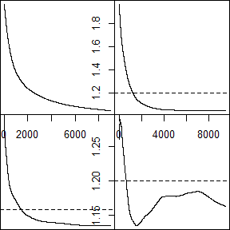

```r
library(StatComp20006)
k <- 4    # four chains
x0 <- c(-10,-5,5,10)    # overdispersed initial values
N <- 10000    # length of chains
b <- 200    # burn-in length

opar <- par(mfrow=c(2,2),mar=rep(0,4))
set.seed(123)
X <- matrix(nrow=k,ncol=N)
for (i in 1:k)
  X[i,] <- rwMetropolisR(N,0.5,x0[i])$x
psi <- t(apply(X, 1, cumsum))
for (i in 1:nrow(psi))
psi[i,] <- psi[i,] / (1:ncol(psi))
rhat <- rep(0, N)
for (j in (1000+1):N)
rhat[j] <- Gelman.Rubin(psi[,1:j])
plot(rhat[(1000+1):N], type="l", xlab="sigma=0.5", ylab="R_hat")
abline(h=1.2, lty=2)

X <- matrix(nrow=k,ncol=N)
for (i in 1:k)
  X[i,] <- rwMetropolisR(N,1,x0[i])$x
psi <- t(apply(X, 1, cumsum))
for (i in 1:nrow(psi))
psi[i,] <- psi[i,] / (1:ncol(psi))
rhat <- rep(0, N)
for (j in (500+1):N)
rhat[j] <- Gelman.Rubin(psi[,1:j])
x2 <- min(which(rhat>0 & rhat<1.2))
plot(rhat[(500+1):N], type="l", xlab="sigma=1", ylab="R_hat")
abline(h=1.2, lty=2)

X <- matrix(nrow=k,ncol=N)
for (i in 1:k)
  X[i,] <- rwMetropolisR(N,4,x0[i])$x
psi <- t(apply(X, 1, cumsum))
for (i in 1:nrow(psi))
psi[i,] <- psi[i,] / (1:ncol(psi))
rhat <- rep(0, N)
for (j in (b+1):N)
rhat[j] <- Gelman.Rubin(psi[,1:j])
x3 <- min(which(rhat>0 & rhat<1.2))
plot(rhat[(b+1):N], type="l", xlab="sigma=4", ylab="R_hat")
abline(h=1.2, lty=2)

X <- matrix(nrow=k,ncol=N)
for (i in 1:k)
  X[i,] <- rwMetropolisR(N,16,x0[i])$x
psi <- t(apply(X, 1, cumsum))
for (i in 1:nrow(psi))
psi[i,] <- psi[i,] / (1:ncol(psi))
rhat <- rep(0, N)
for (j in (b+1):N)
rhat[j] <- Gelman.Rubin(psi[,1:j])
x4 <- min(which(rhat>0 & rhat<1.2))
plot(rhat[(b+1):N], type="l", xlab="sigma=16", ylab="R_hat")
abline(h=1.2, lty=2)
```

```r
par(opar)

c(x2,x3,x4)
```

```
## [1] 1715 1762  849
```

## Question11.4

Find the intersection points $A(k)$ in $(0,\sqrt{k})$ of the curves
$$\begin{equation}
S_{k-1}(a)=P(t(k-1)>\sqrt{\frac{a^2(k-1)}{k-a^2}})
\end{equation}$$
and
$$\begin{equation}
S_k(a)=P(t(k)>\sqrt{\frac{a^2 k}{k+1-a^2}}),
\end{equation}$$

for $k = 4 : 25, 100, 500, 1000$, where $t(k)$ is a Student $t$ random variable with $k$ degrees of freedom. (These intersection points determine the critical values for a $t$-test for scale-mixture errors.)

## Answer

```r
inter.points <- function(k){
  S = function(a,k){
    ck = sqrt(a^2*k/(k+1-a^2))
    pt(ck,df=k,lower.tail=FALSE)
  }
  solve = function(k){
    output = uniroot(function(a){S(a,k)-S(a,k-1)},lower=1,upper=2)
    output$root
  }
  root = matrix(0,2,length(k))
  for (i in 1:length(k)){
    root[2,i]=round(solve(k[i]),4)
  }
  root[1,] = k
  rownames(root) = c('k','A(k)')
  root
}
```

```r
library(StatComp20006)
k = c(4:25,100,500,1000)
root <- inter.points(k)
print(root)
```

```
##        [,1]   [,2]   [,3]   [,4]   [,5]   [,6]    [,7]    [,8]   [,9]   [,10]
## k    4.0000 5.0000 6.0000 7.0000 8.0000 9.0000 10.0000 11.0000 12.000 13.0000
## A(k) 1.4921 1.5336 1.5627 1.5844 1.6012 1.6145  1.6254  1.6344  1.642  1.6486
##        [,11]   [,12]   [,13]   [,14]   [,15]   [,16]   [,17]   [,18]   [,19]
## k    14.0000 15.0000 16.0000 17.0000 18.0000 19.0000 20.0000 21.0000 22.0000
## A(k)  1.6542  1.6591  1.6635  1.6673  1.6707  1.6738  1.6766  1.6792  1.6815
##        [,20]   [,21]   [,22]    [,23]    [,24]     [,25]
## k    23.0000 24.0000 25.0000 100.0000 500.0000 1000.0000
## A(k)  1.6836  1.6856  1.6874   1.7206   1.7298    1.7309
```

## Homework-11-24

## A-B-O blood type problem

Let the three alleles be A, B and O.

Observed data: A-type: $n_{A \cdot }=444$

B-type: $n_{B \cdot }=132$

O-type: $n_{OO}=361$

AB-type: $n_{AB}=63$

1. Use EM algorithm to solve MLE of $p$ and $q$. (consider missing data $n_{AA}$ and $n_{BB}$)
2. Record the values of $p$ and $q$ that maximize the conditional likelihood in each EM steps, calculate the corresponding log-maximum likelihood values (for observed data), are they increasing? ### Answer

```r
EM_blood <- function(n.A,n.B,nOO,nAB){
  # Mle
  eval_f0 = function(x,x1,n.A,n.B,nOO,nAB) {

    r1 = 1-sum(x1)
    nAA = n.A*x1[1]^2/(x1[1]^2+2*x1[1]*r1)
    nBB = n.B*x1[2]^2/(x1[2]^2+2*x1[2]*r1)
    r = 1-sum(x)
    return(-2*nAA*log(x[1])-2*nBB*log(x[2])-2*nOO*log(r)-
             (n.A-nAA)*log(2*x[1]*r)-(n.B-nBB)*log(2*x[2]*r)-nAB*log(2*x[1]*x[2]))
  }


  # constraint
  eval_g0 = function(x,x1,n.A,n.B,nOO,nAB) {
    return(sum(x)-0.999999)
  }

  opts = list("algorithm"="NLOPT_LN_COBYLA",
              "xtol_rel"=1.0e-8)
  mle = NULL
  r = matrix(0,1,2)
  r = rbind(r,c(0.2,0.35))# the beginning value of p0 and q0
  j = 2
  while (sum(abs(r[j,]-r[j-1,]))>1e-8) {
    res = nloptr( x0=c(0.2,0.25),
                  eval_f=eval_f0,
                  lb = c(0,0), ub = c(1,1),
                  eval_g_ineq = eval_g0,
                  opts = opts, x1=r[j,],n.A=n.A,n.B=n.B,nOO=nOO,nAB=nAB)
    j = j+1
    r = rbind(r,res$solution)
    mle = c(mle,eval_f0(x=r[j,],x1=r[j-1,],n.A=n.A,n.B=n.B,nOO=nOO,nAB=nAB))
  }
  return(list(r=r,mle=mle))
}
```

```r
library(nloptr)
library(StatComp20006)
n.A <- 444; n.B <- 132; nOO <- 361; nAB <- 63
em <- EM_blood(n.A,n.B,nOO,nAB)
#the result of EM algorithm
em$r
```

```
##            [,1]      [,2]
##  [1,] 0.0000000 0.0000000
##  [2,] 0.2000000 0.3500000
##  [3,] 0.2938636 0.1159800
##  [4,] 0.2977537 0.1034051
##  [5,] 0.2977020 0.1027454
##  [6,] 0.2976539 0.1027089
##  [7,] 0.2976433 0.1027065
##  [8,] 0.2976411 0.1027063
##  [9,] 0.2976407 0.1027063
## [10,] 0.2976407 0.1027063
## [11,] 0.2976407 0.1027063
## [12,] 0.2976407 0.1027063
```

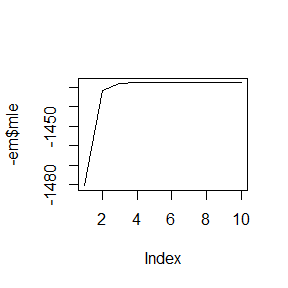

```r
#the max likelihood values
plot(-em$mle,type = 'l')
```

## p204 Exercises 3

Use both for loops and lapply() to fit linear models to the mtcars using the formulas stored in this list:

formulas <- list(

mpg ~ disp,

mpg ~ I(1 / disp),

mpg ~ disp + wt,

mpg ~ I(1 / disp) + wt

)

### Answer

```r
loop_lapply <- function(formulas, data){
  #1 for loops
  lo = vector("list", length(formulas))
  for (i in seq_along(formulas)){
    lo[[i]] = lm(formulas[[i]], data = data)
  }
  la = lapply(formulas, function(x) lm(formula = x, data = data))
  return(list(lo=lo,la=la))
}
```

```r
library(StatComp20006)
data(mtcars)
attach(mtcars)
formulas = list(
  mpg ~ disp,
  mpg ~ I(1 / disp),
  mpg ~ disp + wt,
  mpg ~ I(1 / disp) + wt
)
ll <- loop_lapply(formulas,mtcars)
print(ll$lo)
```

```
## [[1]]
##
## Call:
## lm(formula = formulas[[i]], data = data)
##
## Coefficients:
## (Intercept)         disp
##    29.59985     -0.04122
##
##
## [[2]]
##
## Call:
## lm(formula = formulas[[i]], data = data)
##
## Coefficients:
## (Intercept)    I(1/disp)
##       10.75      1557.67
##
##
## [[3]]
##
## Call:
## lm(formula = formulas[[i]], data = data)
##
## Coefficients:
## (Intercept)         disp           wt
##    34.96055     -0.01772     -3.35083
##
##
## [[4]]
##
## Call:
## lm(formula = formulas[[i]], data = data)
##
## Coefficients:
## (Intercept)    I(1/disp)           wt
##      19.024     1142.560       -1.798
```

```r
print(ll$la)
```

```
## [[1]]
##
## Call:
## lm(formula = x, data = data)
##
## Coefficients:
## (Intercept)         disp
##    29.59985     -0.04122
##
##
## [[2]]
##
## Call:
## lm(formula = x, data = data)
##
## Coefficients:
## (Intercept)    I(1/disp)
##       10.75      1557.67
##
##
## [[3]]
##
## Call:
## lm(formula = x, data = data)
##
## Coefficients:
## (Intercept)         disp           wt
##    34.96055     -0.01772     -3.35083
##
##
## [[4]]
##
## Call:
## lm(formula = x, data = data)
##
## Coefficients:
## (Intercept)    I(1/disp)           wt
##      19.024     1142.560       -1.798
```

## p214 Exercises 3

The following code simulates the performance of a t-test for non-normal data. Use sapply() and an anonymous function to extract the p-value from every trial.

### Answer

```r
sapply_t_p <- function(){
  trials = replicate(
    100,
    t.test(rpois(10, 10), rpois(7, 10)),
    simplify = FALSE
  )
  # anonymous function:
  p <- sapply(trials, function(x) x[["p.value"]])
  return(p)
}
```

```r
library(StatComp20006)
set.seed(123)
p <- sapply_t_p()
print(p)
```

```
##   [1] 9.813226e-01 1.619096e-05 6.242135e-01 6.693526e-01 5.677105e-01
##   [6] 6.610740e-01 5.951636e-01 5.005347e-01 4.763110e-01 3.429965e-01
##  [11] 8.155394e-01 7.197238e-01 1.244336e-01 2.229164e-01 1.113099e-02
##  [16] 4.625765e-01 6.515865e-01 1.658793e-01 9.342672e-01 8.011934e-01
##  [21] 4.627657e-01 5.927934e-01 2.929669e-01 5.737967e-01 3.451537e-02
##  [26] 2.739138e-01 2.656151e-01 8.196695e-01 6.647355e-01 8.056529e-01
##  [31] 5.060850e-01 7.106543e-01 2.321066e-01 1.106223e-01 5.459279e-01
##  [36] 1.865470e-02 2.433776e-01 2.688851e-01 9.819256e-01 4.940184e-01
##  [41] 3.268275e-01 8.000439e-01 9.822499e-01 1.936454e-01 7.390101e-01
##  [46] 3.888930e-02 4.350424e-01 7.434339e-02 5.787441e-01 4.864951e-01
##  [51] 1.476288e-01 5.524909e-01 7.129280e-01 8.683479e-03 9.053256e-02
##  [56] 4.415463e-01 4.955063e-01 1.745328e-01 6.615399e-01 4.479199e-01
##  [61] 2.885849e-01 3.028567e-02 1.018907e-01 1.811861e-02 6.376441e-01
##  [66] 1.408742e-02 9.008128e-02 4.515933e-01 8.703291e-01 7.250768e-01
##  [71] 8.183571e-01 8.465036e-01 8.786838e-01 1.651543e-01 3.951569e-01
##  [76] 1.754280e-01 3.649865e-01 7.224226e-02 6.565152e-01 9.946559e-01
##  [81] 3.715952e-01 8.424336e-02 4.549887e-01 8.530113e-01 1.970777e-01
##  [86] 2.298117e-01 1.148832e-01 7.769502e-01 4.934348e-01 3.526049e-01
##  [91] 2.036013e-01 8.838914e-01 6.474880e-02 4.089082e-01 5.780132e-01
##  [96] 8.011408e-01 5.956061e-01 9.266689e-01 9.923205e-02 1.763972e-01
```

## p214 Exercises 6

Implement a combination of Map() and vapply() to create an lapply() variant that iterates in parallel over all of its inputs and stores its outputs in a vector (or a matrix). What arguments should the function take?

### Answer

We use the dataset mtcars and faithful as the example, what we expect is something like the following result:

```r
library(StatComp20006)
data(mtcars); data(faithful)
datalist <- list(mtcars, faithful)
lapply(datalist, function(x) vapply(x, mean, numeric(1)))
```

```
## [[1]]
##        mpg        cyl       disp         hp       drat         wt       qsec
##  20.090625   6.187500 230.721875 146.687500   3.596563   3.217250  17.848750
##         vs         am       gear       carb
##   0.437500   0.406250   3.687500   2.812500
##
## [[2]]
## eruptions   waiting
##  3.487783 70.897059
```

We can get similar result with the following function:

```r
mylapply <- function(X, FUN, FUN.VALUE, simplify = FALSE){
  out <- Map(function(x) vapply(x, FUN, FUN.VALUE), X)
  if(simplify == TRUE) return(simplify2array(out))
  unlist(out)
}
```

```r
mylapply(datalist,mean,numeric(1))
```

```
##        mpg        cyl       disp         hp       drat         wt       qsec
##  20.090625   6.187500 230.721875 146.687500   3.596563   3.217250  17.848750
##         vs         am       gear       carb  eruptions    waiting
##   0.437500   0.406250   3.687500   2.812500   3.487783  70.897059
```

## Homework-12-01

## Question

1. Write an Rcpp function for Exercise 9.4 (page 277, Statistical Computing with R).
2. Compare the corresponding generated random numbers with those by the R function you wrote before using the function “qqplot”.
3. Campare the computation time of the two functions with the function “microbenchmark”.
4. Comments your results.

## Answer

```r
#include <cmath>
#include <Rcpp.h>
using namespace Rcpp;

//[[Rcpp::export]]
NumericVector rwMetropolisC(int N, double sigma, double x0) {
  NumericVector x(N);
  x[0] = x0;
  NumericVector u = runif(N);
  for (int i = 1; i < N;i++ ) {
    NumericVector y = rnorm(1, x[i-1], sigma);
    if (u[i] <= exp(abs(x[i-1])-abs(y[0]))){
      x[i] = y[0];
    }
    else {
      x[i] = x[i-1];
    }
  }
  return(x);
}
```

```r
library(microbenchmark)

rwMetropolisR <- function(N,sigma,x0){
  x <- numeric(N)
  x[1] <- x0
  u <- runif(N)
  k <- 0
  for (i in 2:N) {
    y <- rnorm(1,x[i-1],sigma)
    if(u[i] <= exp(abs(x[i-1])-abs(y))){
      x[i] <- y
    }else{
      x[i] <- x[i-1]
      k <- k+1
    }
  }
  return(list(x=x,k=k))
}
```

```r
library(StatComp20006)
library(microbenchmark)

x0 = 25; N = 2000; sigma = 2
ts <- microbenchmark(rwR = rwMetropolisR(N,sigma,x0), rwC = rwMetropolisC(N,sigma,x0))
summary(ts)[,c(1,3,5,6)]
```

```
##   expr      lq  median       uq
## 1  rwR 6592.10 8621.90 10516.55
## 2  rwC  396.55  473.05   649.60
```

From the result above, we can see that the running time of using Cpp is much shorter than using R.

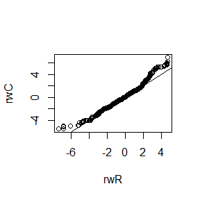

```r
#qqplot
set.seed(123456)
rwR = rwMetropolisR(N,sigma,x0)$x[-(1:500)]
rwC = rwMetropolisC(N,sigma,x0)[-(1:500)]
qqplot(rwR,rwC)
abline(a=0,b=1,col='black')
```

The image of qqplot is close to the diagonal line, which suggets that the random numbers generated by two functions are similar.

## Function 1

Use function knn.dist() in package FNN to write a kth nearest neighbor density estimate function.

```r
library(FNN)
library(StatComp20006)
data(faithful)
X <- as.matrix(faithful)
cat(range(X[,1]),range(X[,2]))
```

```
## 1.6 5.1 43 96
```

[figure not shown]

```r
xrange <- seq(from=1,to=6,by=.1)
yrange <- seq(from=40,to=100,by=.5)
k <- 5
fit_knnde <- knn.est(X, k, xrange, yrange)
persp(xrange, yrange, fit_knnde, phi = 30, theta = 45, border = 0, col = "blue")
```

## Function 2

Use nonparametric method to build hypothesis test for two random vectors' independence by calculating its T value.

```r
Tstat <- function(x, y){ # return T
  n <- length(x) # number of samples
  hx <- hpi(x) # bandwidth for x
  hy <- hpi(y) # bandwidth for y
  fx <- rep(0, n)
  fy <- rep(0, n)
  # leave-one-out kernel estimators of f(x),f(y)
  Kx <- matrix(rep(0, n^2),n)
  Ky <- matrix(rep(0, n^2),n)
  # The (i,j)-th element of Kx is K_hx(Xj-Xi)
  # Compute K: Gaussian kernel
  index <- 1:n
  for (i in index) {
    for (j in index[-i]) {
      Kx[i,j] <- dnorm((x[j] - x[i]) / hx)/ hx
      Ky[i,j] <- dnorm((y[j] - y[i]) / hy)/ hy
    }
  }
  fx <- n / (n-1) * colMeans(Kx)
  fy <- n / (n-1) * colMeans(Ky)
  I <- n / (n-1) * mean(Kx * Ky) + mean(fx %*% t(fy)) - 2 * mean(fx * fy)
  sigma <- sqrt(2 * sum(Kx^2 * Ky^2) / (n^2 * hx * hy))
  T <- n * sqrt(hx * hy) * I / sigma
  return(T)
}
```

Use leave-one-out method and bootstrap to test whether 'eruptions' and 'waiting' in dataset 'faithful' are independent.

```r
library(StatComp20006)
set.seed(0)
alpha <- 0.05 # alpha for the test
x.true <- as.numeric(faithful[,1]) # x is for eruptions
y.true <- as.numeric(faithful[,2]) # y is for waiting
n <- length(x.true) # number of samples
B <- 20 # bootstrap time

### (1) leave-one-out method
T.true <- Tstat(x.true, y.true)
if (abs(T.true) > qnorm(1 - alpha / 2)){
cat('Using leave-one-out, we reject independent structure.')
} else{
cat('Using leave-one-out, we accept independent structure.')
}
```

```
## Using leave-one-out, we reject independent structure.
```

```r
### (2) Boostrap
Tstar <- rep(0,B)
for (i in 1:B) {
xstar <- sample(x.true, n, replace = TRUE)
ystar <- sample(x.true, n, replace = TRUE)
Tstar[i] <- Tstat(xstar, ystar)
} # Bootstrap
p.boot <- mean(T.true < Tstar)
if (p.boot < alpha){
cat('Using bootstrap, we reject independent structure.')
} else{
cat('Using bootstrap, we accept independent structure.')
}
```

```
## Using bootstrap, we reject independent structure.
```

```r
### (3) Compare the two methods
cat('p-value for true T statistics is: ', pnorm(-abs(T.true)) * 2)
```

```
## p-value for true T statistics is:  6.373953e-32
```

```r
cat('p-value for the bootstrap method is: ', p.boot)
```

```
## p-value for the bootstrap method is:  0
```